# Final_Project_CS5300_ChrisHan

```python
import random

import numpy as np
from numpy import savetxt

import matplotlib.pyplot as plt
import pandas as pd

from keras.callbacks import EarlyStopping, ModelCheckpoint
from sklearn.metrics import accuracy_score
from sklearn.utils import shuffle
from tensorflow.keras.models import Sequential
from tensorflow.keras.layers import Dense
```

## **Phase 1: Data analysis & preparation**

I selected a diabetes dataset, as it was always a disease of interest studied by my father before he retired. And frankly, I find most datasets are about finance, or about other trivialities not worth the study (such as MBTI personality tests), which are quite boring to me.

The dataset is taken from here:

https://www.kaggle.com/datasets/alexteboul/diabetes-health-indicators-dataset?resource=download

```python
df = pd.read_csv("diabetes_binary_5050split_health_indicators_BRFSS2015.csv", sep=",")
df
```

|  | Diabetes_binary | HighBP | HighChol | CholCheck | BMI | Smoker | Stroke | HeartDiseaseorAttack | PhysActivity | Fruits | ... | AnyHealthcare | NoDocbcCost | GenHlth | MentHlth | PhysHlth | DiffWalk | Sex | Age | Education | Income |
| --- | --- | --- | --- | --- | --- | --- | --- | --- | --- | --- | --- | --- | --- | --- | --- | --- | --- | --- | --- | --- | --- |
| 0 | 0.0 | 1.0 | 0.0 | 1.0 | 26.0 | 0.0 | 0.0 | 0.0 | 1.0 | 0.0 | ... | 1.0 | 0.0 | 3.0 | 5.0 | 30.0 | 0.0 | 1.0 | 4.0 | 6.0 | 8.0 |
| 1 | 0.0 | 1.0 | 1.0 | 1.0 | 26.0 | 1.0 | 1.0 | 0.0 | 0.0 | 1.0 | ... | 1.0 | 0.0 | 3.0 | 0.0 | 0.0 | 0.0 | 1.0 | 12.0 | 6.0 | 8.0 |
| 2 | 0.0 | 0.0 | 0.0 | 1.0 | 26.0 | 0.0 | 0.0 | 0.0 | 1.0 | 1.0 | ... | 1.0 | 0.0 | 1.0 | 0.0 | 10.0 | 0.0 | 1.0 | 13.0 | 6.0 | 8.0 |
| 3 | 0.0 | 1.0 | 1.0 | 1.0 | 28.0 | 1.0 | 0.0 | 0.0 | 1.0 | 1.0 | ... | 1.0 | 0.0 | 3.0 | 0.0 | 3.0 | 0.0 | 1.0 | 11.0 | 6.0 | 8.0 |
| 4 | 0.0 | 0.0 | 0.0 | 1.0 | 29.0 | 1.0 | 0.0 | 0.0 | 1.0 | 1.0 | ... | 1.0 | 0.0 | 2.0 | 0.0 | 0.0 | 0.0 | 0.0 | 8.0 | 5.0 | 8.0 |
| ... | ... | ... | ... | ... | ... | ... | ... | ... | ... | ... | ... | ... | ... | ... | ... | ... | ... | ... | ... | ... | ... |
| 70687 | 1.0 | 0.0 | 1.0 | 1.0 | 37.0 | 0.0 | 0.0 | 0.0 | 0.0 | 0.0 | ... | 1.0 | 0.0 | 4.0 | 0.0 | 0.0 | 0.0 | 0.0 | 6.0 | 4.0 | 1.0 |
| 70688 | 1.0 | 0.0 | 1.0 | 1.0 | 29.0 | 1.0 | 0.0 | 1.0 | 0.0 | 1.0 | ... | 1.0 | 0.0 | 2.0 | 0.0 | 0.0 | 1.0 | 1.0 | 10.0 | 3.0 | 6.0 |
| 70689 | 1.0 | 1.0 | 1.0 | 1.0 | 25.0 | 0.0 | 0.0 | 1.0 | 0.0 | 1.0 | ... | 1.0 | 0.0 | 5.0 | 15.0 | 0.0 | 1.0 | 0.0 | 13.0 | 6.0 | 4.0 |
| 70690 | 1.0 | 1.0 | 1.0 | 1.0 | 18.0 | 0.0 | 0.0 | 0.0 | 0.0 | 0.0 | ... | 1.0 | 0.0 | 4.0 | 0.0 | 0.0 | 1.0 | 0.0 | 11.0 | 2.0 | 4.0 |
| 70691 | 1.0 | 1.0 | 1.0 | 1.0 | 25.0 | 0.0 | 0.0 | 1.0 | 1.0 | 1.0 | ... | 1.0 | 0.0 | 2.0 | 0.0 | 0.0 | 0.0 | 0.0 | 9.0 | 6.0 | 2.0 |

70692 rows × 22 columns

The data is shuffled and then saved to a new csv file. This reshuffling code is then commented out to prevent accidental reshuffling. If any part of the project needs to be re-written or run again, we can reload this file for a reproducible data set.

```python
#df = shuffle(df)
#df.to_csv('diabetes_my_shuffled.csv', sep=',', index=False)
```

```python
df = pd.read_csv("diabetes_my_shuffled.csv", sep=",")
df = df.astype('int')
df.to_csv('diabetes_my_shuffled.csv', sep=',', index=False)
df
```

|  | Diabetes_binary | HighBP | HighChol | CholCheck | BMI | Smoker | Stroke | HeartDiseaseorAttack | PhysActivity | Fruits | ... | AnyHealthcare | NoDocbcCost | GenHlth | MentHlth | PhysHlth | DiffWalk | Sex | Age | Education | Income |
| --- | --- | --- | --- | --- | --- | --- | --- | --- | --- | --- | --- | --- | --- | --- | --- | --- | --- | --- | --- | --- | --- |
| 0 | 0 | 1 | 1 | 1 | 28 | 1 | 0 | 0 | 0 | 1 | ... | 1 | 0 | 2 | 0 | 0 | 0 | 0 | 11 | 6 | 6 |
| 1 | 1 | 1 | 1 | 1 | 46 | 1 | 0 | 0 | 1 | 1 | ... | 1 | 0 | 4 | 30 | 30 | 1 | 0 | 8 | 5 | 6 |
| 2 | 0 | 1 | 1 | 1 | 25 | 0 | 1 | 1 | 0 | 0 | ... | 1 | 1 | 4 | 5 | 2 | 0 | 0 | 10 | 3 | 4 |
| 3 | 0 | 0 | 1 | 1 | 38 | 1 | 0 | 0 | 1 | 0 | ... | 1 | 0 | 3 | 5 | 0 | 0 | 0 | 6 | 4 | 6 |
| 4 | 0 | 0 | 0 | 1 | 24 | 0 | 0 | 0 | 1 | 1 | ... | 1 | 0 | 2 | 0 | 4 | 0 | 0 | 8 | 5 | 8 |
| ... | ... | ... | ... | ... | ... | ... | ... | ... | ... | ... | ... | ... | ... | ... | ... | ... | ... | ... | ... | ... | ... |
| 70686 | 0 | 0 | 0 | 1 | 24 | 1 | 0 | 0 | 0 | 1 | ... | 1 | 0 | 2 | 0 | 0 | 0 | 0 | 7 | 6 | 8 |
| 70687 | 1 | 0 | 1 | 1 | 28 | 1 | 0 | 0 | 1 | 1 | ... | 1 | 0 | 3 | 0 | 0 | 0 | 1 | 10 | 6 | 4 |
| 70688 | 1 | 1 | 1 | 1 | 29 | 1 | 0 | 1 | 1 | 1 | ... | 1 | 0 | 3 | 0 | 15 | 0 | 1 | 9 | 4 | 6 |
| 70689 | 1 | 1 | 1 | 1 | 27 | 1 | 0 | 0 | 0 | 0 | ... | 1 | 1 | 4 | 0 | 14 | 1 | 1 | 9 | 4 | 3 |
| 70690 | 0 | 0 | 1 | 1 | 22 | 1 | 0 | 0 | 0 | 1 | ... | 1 | 0 | 3 | 30 | 25 | 1 | 0 | 5 | 6 | 1 |

70691 rows × 22 columns

```python
#dataset = np.loadtxt('diabetes_binary_5050split_health_indicators_BRFSS2015.csv', delimiter=",", skiprows=1)
#np.random.shuffle(dataset)
#savetxt('diabetes_my_shuffled.csv', dataset, delimiter=',')
```

```python
dataset = np.loadtxt('diabetes_my_shuffled.csv', delimiter=",", skiprows=1)
```

```python
dataset
```

```
array([[ 0.,  1.,  1., ..., 11.,  6.,  6.],
       [ 1.,  1.,  1., ...,  8.,  5.,  6.],
       [ 0.,  1.,  1., ..., 10.,  3.,  4.],
       ...,
       [ 1.,  1.,  1., ...,  9.,  4.,  6.],
       [ 1.,  1.,  1., ...,  9.,  4.,  3.],
       [ 0.,  0.,  1., ...,  5.,  6.,  1.]])
```

I do some pre-processing and data analysis. We see here there's a roughly even split of diabetes and non-diabetes cases. As examples of both targets are well-represented, we shouldn't need any special measures to account for any skewing that may occur.

```
Proportion of Trues:  0.4999858541277655
```

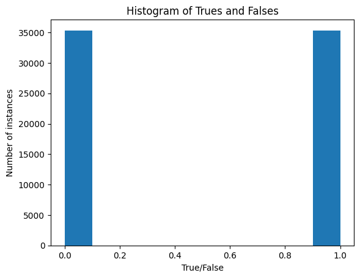

```python
print('Proportion of Trues: ', sum(Y_Overfit)/70692)
print()
plt.hist(df['Diabetes_binary'])
plt.title('Histogram of Trues and Falses')
plt.xlabel('True/False')
plt.ylabel('Number of instances')
plt.show()
```

```python
for i in range(21):
  X_Overfit[:, i] = X_Overfit[:, i] / X_Overfit[:, i].max()
  #print(X_Overfit[:, i])
  #print()
```

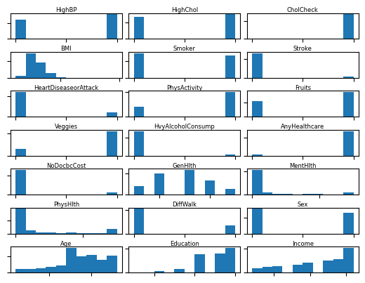

```python
header = list(df.columns)

fig = plt.figure()
fig.subplots_adjust(hspace=0.5, wspace=0.06)

for i in range(21):
  plt.subplot(7, 3, i+1)
  plt.hist(df[header[i+1]])
  plt.title(header[i+1], fontsize=6, pad=1.1)
  ax = plt.gca()
  ax.axes.xaxis.set_ticklabels([])
  ax.axes.yaxis.set_ticklabels([])
```

# **Initial Overfit Trial**

For now, we do not split the data set. I attempt to force a model to overfit to get a sense of what architecture I might need. However, this proves to be quite difficult, as I cannot achieve much greater than a ~75% training accuracy.

Below, I create a training set entirely comprised of all the samples inside the set.

```python
X_Overfit = dataset[:, 1:]
Y_Overfit = dataset[:, 0]

print(np.shape(X_Overfit))
print(np.shape(Y_Overfit))
```

```
(70691, 21)
(70691,)
```

The function below is intended to automate the process of building neural net models. It then uses the constructed model to make predictions on the data set used to train it. For now, we do not concern ourselves with validation.

```python
def test_model(neuron_arr, X, Y, num_epochs, num_batch, is_verbose):
  length = len(neuron_arr)
  my_model = Sequential()
  #
  if length == 1:
    my_model.add(Dense(neuron_arr[0], input_dim = len(X[0, :]), activation='sigmoid'))
  elif length == 2:
    my_model.add(Dense(neuron_arr[0], input_dim = len(X[0, :]), activation='relu'))
    my_model.add(Dense(neuron_arr[1], activation='sigmoid'))
  else:
    for i in range(0, length-1):
      my_model.add(Dense(neuron_arr[i], activation='relu'))
    my_model.add(Dense(neuron_arr[length-1], activation='sigmoid'))
  #
  my_model.compile(loss='binary_crossentropy', optimizer='rmsprop', metrics=['accuracy'])
  my_model.fit(x=X, y=Y, epochs=num_epochs, batch_size=num_batch, verbose=is_verbose, shuffle=True)
  print('Predicting')
  overfit_predict = (my_model.predict(X) > 0.5).astype(int)
  print()
  print('Final accuracy was found to be: ', accuracy_score(Y, overfit_predict))
  return my_model
```

This is testing a logistic regression model.

```python
model0 = test_model([1], X_Overfit, Y_Overfit, 16, 32, 1)
```

```
Predicting

Final accuracy was found to be:  0.7410137075441003
```

The summary below is simply to verify that the model produced by my function has the expected architecture. This formate will be used consistently throughout this phase of the project.

```python
model0.summary()
```

```
Model: "sequential_49"
_________________________________________________________________
 Layer (type)                Output Shape              Param #
=================================================================
 dense_116 (Dense)           (None, 1)                 22

=================================================================
Total params: 22
Trainable params: 22
Non-trainable params: 0
_________________________________________________________________
```

This is testing 2-1 architecure.

```python
model1 = test_model([2, 1], X_Overfit, Y_Overfit, 16, 32, 1)
```

```
Predicting

Final accuracy was found to be:  0.7470399343622244
```

```python
model1.summary()
```

```
Model: "sequential_52"
_________________________________________________________________
 Layer (type)                Output Shape              Param #
=================================================================
 dense_120 (Dense)           (None, 2)                 44

 dense_121 (Dense)           (None, 1)                 3

=================================================================
Total params: 47
Trainable params: 47
Non-trainable params: 0
_________________________________________________________________
```

4-2-1 Neural Network Model

```python
model2 = test_model([4, 2, 1], X_Overfit, Y_Overfit, 16, 32, 1)
```

```
Predicting

Final accuracy was found to be:  0.7502793849287746
```

```python
model2.summary()
```

```
Model: "sequential_53"
_________________________________________________________________
 Layer (type)                Output Shape              Param #
=================================================================
 dense_122 (Dense)           (None, 4)                 88

 dense_123 (Dense)           (None, 2)                 10

 dense_124 (Dense)           (None, 1)                 3

=================================================================
Total params: 101
Trainable params: 101
Non-trainable params: 0
_________________________________________________________________
```

8-4-2-1 Neural Network Model

```python
model3 = test_model([8, 4, 2, 1], X_Overfit, Y_Overfit, 16, 32, 1)
```

```
Predicting

Final accuracy was found to be:  0.7449180235107722
```

```python
model3.summary()
```

```
Model: "sequential_55"
_________________________________________________________________
 Layer (type)                Output Shape              Param #
=================================================================
 dense_129 (Dense)           (None, 8)                 176

 dense_130 (Dense)           (None, 4)                 36

 dense_131 (Dense)           (None, 2)                 10

 dense_132 (Dense)           (None, 1)                 3

=================================================================
Total params: 225
Trainable params: 225
Non-trainable params: 0
_________________________________________________________________
```

16-8-4-2-1 Neural Network Model

```python
model4 = test_model([16, 8, 4, 2, 1], X_Overfit, Y_Overfit, 16, 32, 1)
```

```
Predicting

Final accuracy was found to be:  0.7516091157290178
```

```python
model4.summary()
```

```
Model: "sequential_56"
_________________________________________________________________
 Layer (type)                Output Shape              Param #
=================================================================
 dense_133 (Dense)           (None, 16)                352

 dense_134 (Dense)           (None, 8)                 136

 dense_135 (Dense)           (None, 4)                 36

 dense_136 (Dense)           (None, 2)                 10

 dense_137 (Dense)           (None, 1)                 3

=================================================================
Total params: 537
Trainable params: 537
Non-trainable params: 0
_________________________________________________________________
```

128-64-32-16-8-4-2-1 Neural Network Model

```python
model5 = test_model([128, 64, 32, 16, 8, 4, 2, 1], X_Overfit, Y_Overfit, 16, 32, 1)
```

```
Predicting

Final accuracy was found to be:  0.7539007794485861
```

```python
model5.summary()
```

```
Model: "sequential_57"
_________________________________________________________________
 Layer (type)                Output Shape              Param #
=================================================================
 dense_138 (Dense)           (None, 128)               2816

 dense_139 (Dense)           (None, 64)                8256

 dense_140 (Dense)           (None, 32)                2080

 dense_141 (Dense)           (None, 16)                528

 dense_142 (Dense)           (None, 8)                 136

 dense_143 (Dense)           (None, 4)                 36

 dense_144 (Dense)           (None, 2)                 10

 dense_145 (Dense)           (None, 1)                 3

=================================================================
Total params: 13,865
Trainable params: 13,865
Non-trainable params: 0
_________________________________________________________________
```

1024-1 Neural Network Model

```python
model6 = test_model([1024, 1], X_Overfit, Y_Overfit, 16, 32, 1)
```

```
Predicting

Final accuracy was found to be:  0.7520617900439943
```

```python
model6.summary()
```

```
Model: "sequential_58"
_________________________________________________________________
 Layer (type)                Output Shape              Param #
=================================================================
 dense_146 (Dense)           (None, 1024)              22528

 dense_147 (Dense)           (None, 1)                 1025

=================================================================
Total params: 23,553
Trainable params: 23,553
Non-trainable params: 0
_________________________________________________________________
```

512-256-128-64-32-16-8-4-2-1 Neural Network Model

```python
model7 = test_model([512, 256, 128, 64, 32, 16, 8, 4, 2, 1], X_Overfit, Y_Overfit, 16, 32, 1)
```

```
Predicting

Final accuracy was found to be:  0.7539007794485861
```

```python
model7.summary()
```

```
Model: "sequential_59"
_________________________________________________________________
 Layer (type)                Output Shape              Param #
=================================================================
 dense_148 (Dense)           (None, 512)               11264

 dense_149 (Dense)           (None, 256)               131328

 dense_150 (Dense)           (None, 128)               32896

 dense_151 (Dense)           (None, 64)                8256

 dense_152 (Dense)           (None, 32)                2080

 dense_153 (Dense)           (None, 16)                528

 dense_154 (Dense)           (None, 8)                 136

 dense_155 (Dense)           (None, 4)                 36

 dense_156 (Dense)           (None, 2)                 10

 dense_157 (Dense)           (None, 1)                 3

=================================================================
Total params: 186,537
Trainable params: 186,537
Non-trainable params: 0
_________________________________________________________________
```

4-1 Neural Network Model

```python
model8 = test_model([4, 1], X_Overfit, Y_Overfit, 16, 32, 1)
```

```
Predicting

Final accuracy was found to be:  0.7504349917245476
```

```python
model8.summary()
```

```
Model: "sequential_60"
_________________________________________________________________
 Layer (type)                Output Shape              Param #
=================================================================
 dense_158 (Dense)           (None, 4)                 88

 dense_159 (Dense)           (None, 1)                 5

=================================================================
Total params: 93
Trainable params: 93
Non-trainable params: 0
_________________________________________________________________
```

I am not successful with forcing an overfit, as most models result in a ~75% accuracy. I decide to move to the next phase and just determine which model to use by plotting accuracy curves with more rigorous testing.

## Phase 3: Model selection & evaluation

Once again, I decide to automate the process of more rigorous model-testing with a couple different functions and create a 20-80 split between the testing and validation data.

The function below generates a model and returns both the training and accuracy scores. The history is returned and fed into a plotting function for visualizing the fit.

```python
def build_model(neuron_arr, XTRAIN, YTRAIN, XVALID, YVALID, num_epochs, num_batch, is_verbose):
  length = len(neuron_arr)
  my_model = Sequential()
  #
  if length == 1:
    my_model.add(Dense(neuron_arr[0], input_dim = len(XTRAIN[0, :]), activation='sigmoid'))
  elif length == 2:
    my_model.add(Dense(neuron_arr[0], input_dim = len(XTRAIN[0, :]), activation='relu'))
    my_model.add(Dense(neuron_arr[1], activation='sigmoid'))
  else:
    for i in range(0, length-1):
      my_model.add(Dense(neuron_arr[i], activation='relu'))
    my_model.add(Dense(neuron_arr[length-1], activation='sigmoid'))
  #
  my_model.compile(loss='binary_crossentropy', optimizer='rmsprop', metrics=['accuracy'])
  callback_a = ModelCheckpoint(filepath = 'my_best', monitor='val_loss', save_best_only = True, save_weights_only = True, verbose = 0)
  callback_b = EarlyStopping(monitor='val_loss', mode='min', patience=20, verbose=1)
  history = my_model.fit(XTRAIN, YTRAIN, validation_data = (XVALID, YVALID), epochs=num_epochs, batch_size=num_batch, verbose=is_verbose, callbacks = [callback_a, callback_b])
  print()
  print('TRAINING SET ACCURACY: ', accuracy_score(YTRAIN, (my_model.predict(XTRAIN) > 0.5).astype(int)))
  print()
  print('VALIDATION SET ACCURACY: ', accuracy_score(YVALID, (my_model.predict(XVALID) > 0.5).astype(int)))
  return history

def plot_history (history):
  plt.plot(history.history['accuracy']) # replace with accuracy/MAE
  plt.plot(history.history['val_accuracy']) # replace with val_accuracy, etc.
  plt.ylabel('Accuracy')
  plt.xlabel('epoch')
  plt.legend(['training data', 'validation data'], loc='lower right')
  plt.show()
```

```python
twenty_percent = int(len(dataset[:, 0]) * 0.2)
XTRAIN = dataset[:twenty_percent, 1:] / dataset[:twenty_percent, 1:].max()
YTRAIN = dataset[:twenty_percent, 0] / dataset[:twenty_percent, 0].max()
XVALID = dataset[twenty_percent:, 1:] / dataset[twenty_percent:, 1:].max()
YVALID = dataset[twenty_percent:, 0] / dataset[twenty_percent:, 0].max()

print(np.shape(XTRAIN))
print(np.shape(YTRAIN))
print(np.shape(XVALID))
print(np.shape(YVALID))
```

```
(14138, 21)
(14138,)
(56553, 21)
(56553,)
```

We check the distribution of the true/false classifications on both the training and validation sets to see that shuffling didn't over/under-represent either during the data shuffling.

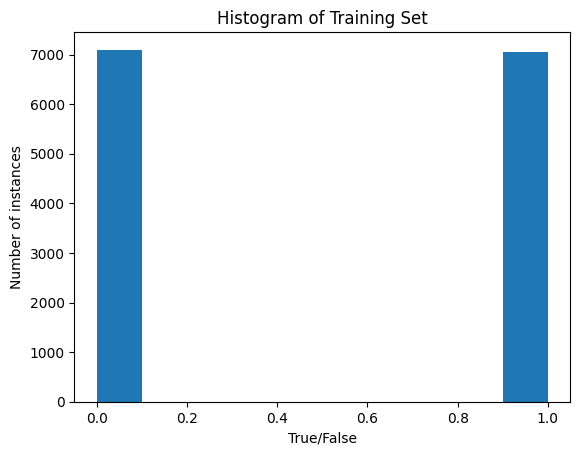

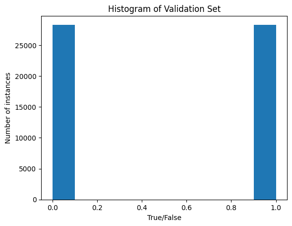

```python
plt.hist(YTRAIN)
plt.title('Histogram of Training Set')
plt.xlabel('True/False')
plt.ylabel('Number of instances')
plt.show()

plt.hist(YVALID)
plt.title('Histogram of Validation Set')
plt.xlabel('True/False')
plt.ylabel('Number of instances')
plt.show()
```

# Logistic Regression Model

```
TRAINING SET ACCURACY:  0.7463573348422691

VALIDATION SET ACCURACY:  0.7465386451647128
```

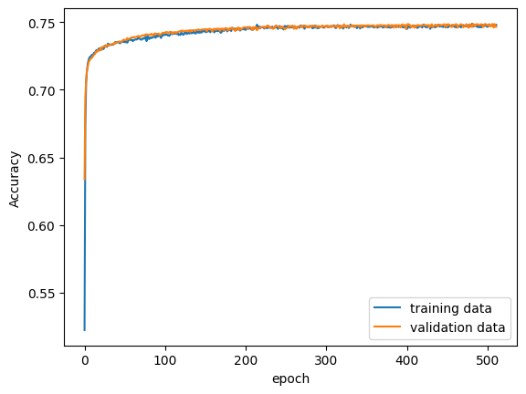

```python
history0 = build_model([1], XTRAIN, YTRAIN, XVALID, YVALID, 512, 32, 0)
print()
plot_history(history0)
```

```python
history0.model.summary()
```

```
Model: "sequential_4"
_________________________________________________________________
 Layer (type)                Output Shape              Param #
=================================================================
 dense_7 (Dense)             (None, 1)                 22

=================================================================
Total params: 22
Trainable params: 22
Non-trainable params: 0
_________________________________________________________________
```

# Neural Network Model (2-1)

```
Epoch 126: early stopping

TRAINING SET ACCURACY:  0.7506012165794314

VALIDATION SET ACCURACY:  0.7491556592930525
```

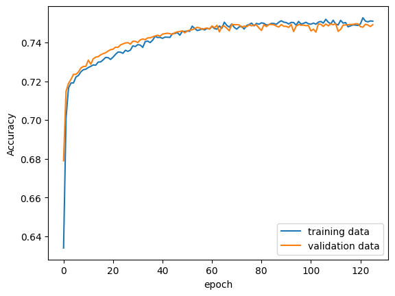

```python
history1 = build_model([2, 1], XTRAIN, YTRAIN, XVALID, YVALID, 512, 32, 0)
print()
plot_history(history1)
```

```python
history1.model.summary()
```

```
Model: "sequential_2"
_________________________________________________________________
 Layer (type)                Output Shape              Param #
=================================================================
 dense_3 (Dense)             (None, 2)                 44

 dense_4 (Dense)             (None, 1)                 3

=================================================================
Total params: 47
Trainable params: 47
Non-trainable params: 0
_________________________________________________________________
```

# Neural Network Model (4-2-1)

```
Epoch 126: early stopping

TRAINING SET ACCURACY:  0.7511670674777197

VALIDATION SET ACCURACY:  0.7486605485120152
```

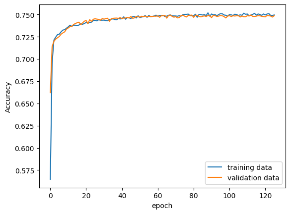

```python
history2 = build_model([4, 2, 1], XTRAIN, YTRAIN, XVALID, YVALID, 512, 32, 0)
print()
plot_history(history2)
```

```python
history2.model.summary()
```

```
Model: "sequential_11"
_________________________________________________________________
 Layer (type)                Output Shape              Param #
=================================================================
 dense_21 (Dense)            (None, 4)                 88

 dense_22 (Dense)            (None, 2)                 10

 dense_23 (Dense)            (None, 1)                 3

=================================================================
Total params: 101
Trainable params: 101
Non-trainable params: 0
_________________________________________________________________
```

# Neural Network Model (512-1)

We can see that this model results in beginning to overfit, as the accuracy of the training prediction overtakes the accuracy of the validation.

```
Epoch 28: early stopping

TRAINING SET ACCURACY:  0.74812561889942

VALIDATION SET ACCURACY:  0.7367778897671211
```

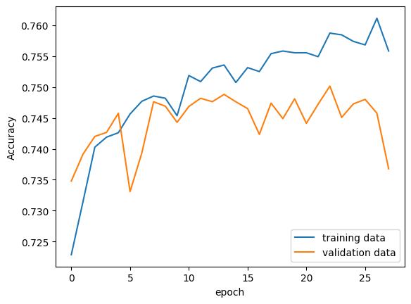

```python
history3 = build_model([512, 1], XTRAIN, YTRAIN, XVALID, YVALID, 512, 32, 0)
print()
plot_history(history3)
```

```python
history3.model.summary()
```

```
Model: "sequential_12"
_________________________________________________________________
 Layer (type)                Output Shape              Param #
=================================================================
 dense_24 (Dense)            (None, 512)               11264

 dense_25 (Dense)            (None, 1)                 513

=================================================================
Total params: 11,777
Trainable params: 11,777
Non-trainable params: 0
_________________________________________________________________
```

# Neural Network Model (1-1)

This model seems thus far the best compromise between fitting, accuracy and speed of training.

```
Epoch 145: early stopping

TRAINING SET ACCURACY:  0.7490451266091385

VALIDATION SET ACCURACY:  0.7488196912630629
```

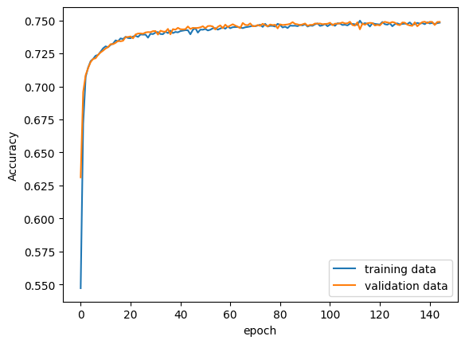

```python
history4 = build_model([1, 1], XTRAIN, YTRAIN, XVALID, YVALID, 512, 32, 0)
print()
plot_history(history4)
```

```python
history4.model.summary()
```

```
Model: "sequential_3"
_________________________________________________________________
 Layer (type)                Output Shape              Param #
=================================================================
 dense_5 (Dense)             (None, 1)                 22

 dense_6 (Dense)             (None, 1)                 2

=================================================================
Total params: 24
Trainable params: 24
Non-trainable params: 0
_________________________________________________________________
```

## Phase 3 (Part 2): Building a Custom Prediction Model

Below is a section of code where I include the output as an additional input feature. This is to determine whether I am on the right track, by whether the validation accuracy reaches 100%.

```
TRAINING SET ACCURACY:  1.0

VALIDATION SET ACCURACY:  1.0
```

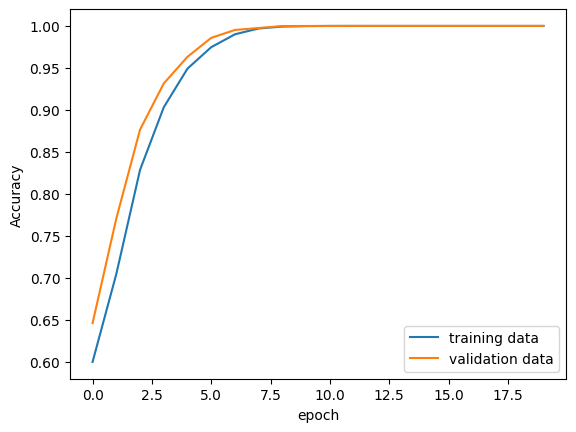

```python
XTRAIN_with_output = dataset[:twenty_percent, :]
XVALID_with_output = dataset[twenty_percent:, :]

#A (1,1) model is produced for the purposes of testing.
history = build_model([1], XTRAIN_with_output, YTRAIN, XVALID_with_output, YVALID, 20, 32, 1)
print()
plot_history(history)
```

I construct a 1-1 Neural Network model below so that I can simulate its results with a custom function.

```
Epoch 141: early stopping

TRAINING SET ACCURACY:  0.7493280520582827

VALIDATION SET ACCURACY:  0.7491556592930525
```

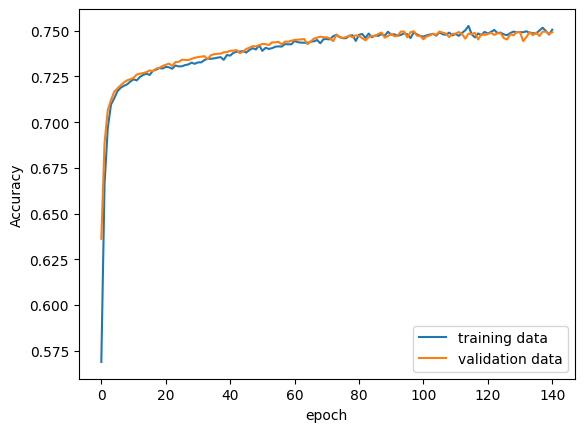

```python
model_to_simulate = build_model([1, 1], XTRAIN, YTRAIN, XVALID, YVALID, 512, 32, 0)
print()
plot_history(model_to_simulate)
```

The custom function below is part of the additional requirements for graduate students. It extracts the necessary weights and bias from the model constructed above and uses them to calculate the predictions.

```python
def my_prediction_function(model, data):
  numOfFeatures = len(data[1])
  numOfSamples = len(data[:])
  numOfLayers = len(model.model.layers)
  w = [None]*numOfFeatures

  # Extract weights of first layer
  for i in range(numOfFeatures):
     w[i] = model.model.layers[0].get_weights()[0][i]
  bias = model.model.layers[0].get_weights()[1]

  #print('Weights extracted . . .')

  # Calculate z of first layer
  z = [0] * numOfSamples
  for row in range(numOfSamples):
    for col in range(numOfFeatures):
      z[row] = z[row] + data[:, col] * w[col]
    z[row] = z[row] + bias
    z[row] = np.maximum(0, z[row])
    #print('Row:', row)

  #print('First layer complete!')

  # Calculate z of second layer
  for row in range(numOfSamples):
    z[row] = z[row] * model.model.layers[1].get_weights()[0][0]
    z[row] = z[row] + model.model.layers[1].get_weights()[1][0]
    result = 1/(1+np.exp(-z[row]))
    result = result.reshape((numOfSamples, 1))

  return result
```

Generating predictions takes a surprising amount of memory, so the predictions are tested across the first 1000 samples in the validation set instead of the entire set.

```python
p1 = model_to_simulate.model.predict(XVALID[:1000])
p2 = my_prediction_function(model_to_simulate, XVALID[:1000])
```

I see from the graph below that the predictions generated by the model and my custom function. As can be seen, they correspond nearly perfectly.

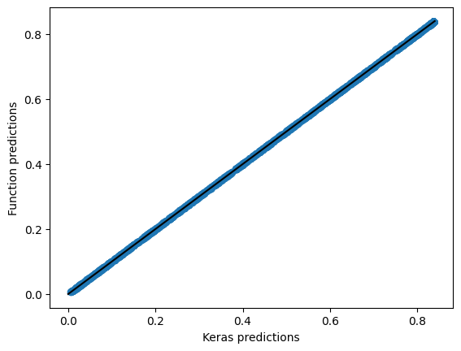

```python
plt.scatter(p1, p2)
plt.title('Check Predictions')
plt.xlabel('Keras predictions')
plt.ylabel('Function predictions')
plt.plot([0,0.84],[0,0.84], color = 'black')
plt.show()
```

A bit of simple arithmetic confirms that the custom function is replicating the same predictions, though there are slight differences in the floating decimals.

```python
sum(p1/p2)
```

```
array([1000.00011855])
```

## Phase 4: Feature importance and reduction

First, I generate a series of 1-1 neural network models for each feature by automating it. Each model only takes in a single feature from the data set. These models are stored in an array of models.

This is to get a rough idea of the relevance of each feature.

```python
singleArr = [None]*21

for i in range(21):
  singleArr[i] = build_model([1, 1], XTRAIN[:, i].reshape((len(XTRAIN[:, i]), 1)), YTRAIN, XVALID[:, i].reshape((len(XVALID[:, i]), 1)), YVALID, 512, 32, 0)
  print()
```

```
Epoch 31: early stopping

TRAINING SET ACCURACY:  0.6933088131277408

VALIDATION SET ACCURACY:  0.6882039856417873

Epoch 21: early stopping

TRAINING SET ACCURACY:  0.49801952185599097

VALIDATION SET ACCURACY:  0.5004862695170902

Epoch 34: early stopping

TRAINING SET ACCURACY:  0.501980478144009

VALIDATION SET ACCURACY:  0.4995137304829098

Epoch 36: early stopping

TRAINING SET ACCURACY:  0.501980478144009

VALIDATION SET ACCURACY:  0.4995137304829098

Epoch 39: early stopping

TRAINING SET ACCURACY:  0.5418022351110482

VALIDATION SET ACCURACY:  0.543224939437342

Epoch 26: early stopping

TRAINING SET ACCURACY:  0.5321827698401471

VALIDATION SET ACCURACY:  0.5298215832935477

Epoch 22: early stopping

TRAINING SET ACCURACY:  0.5760362144574904

```

[output cut: 70 more lines]

```
TRAINING SET ACCURACY:  0.6157872400622436

VALIDATION SET ACCURACY:  0.6170318108676817

Epoch 110: early stopping

TRAINING SET ACCURACY:  0.5587777620596973

VALIDATION SET ACCURACY:  0.5656287022792779

Epoch 31: early stopping

TRAINING SET ACCURACY:  0.49801952185599097

VALIDATION SET ACCURACY:  0.5004862695170902
```

The following code simply reproduces the accuracy scores from the models stored in the array from the previuos step. These scores are also stored in an array for easy retrieval in later steps.

```python
#TrainAcc = [None] * 21
ValidAcc = [None] * 21

for i in range(21):
  #XMOD = singleArr[i].model.predict(XTRAIN[:, i].reshape((len(XTRAIN[:, 0]), 1)))
  #TrainAcc[i] =  accuracy_score(YTRAIN, (XMOD > 0.5).astype(int))
  XMOD = singleArr[i].model.predict(XVALID[:, i].reshape((len(XVALID[:, 0]), 1)))
  ValidAcc[i] =  accuracy_score(YVALID, (XMOD > 0.5).astype(int))
  #print('For i = ', i, ':', 'ACC =', ValidAcc[i])
  print()
```

Below, I have the accuracy values from the array. This is also here so I can also later transcribe the values if need be without having to re-run any code.

```python
ValidAcc
```

```
[0.6882039856417873,
 0.5004862695170902,
 0.4995137304829098,
 0.4995137304829098,
 0.543224939437342,
 0.5298215832935477,
 0.5748236167842555,
 0.4995137304829098,
 0.4995137304829098,
 0.4995137304829098,
 0.5197602249217548,
 0.5051721394090499,
 0.5115732145067459,
 0.6866125581313105,
 0.4995137304829098,
 0.4995137304829098,
 0.618959206408148,
 0.4995137304829098,
 0.6170318108676817,
 0.5656287022792779,
 0.5004862695170902]
```

Afterwards, I can create a bar plot from the gathered validation accuracies.

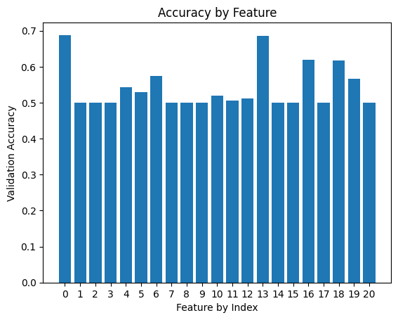

```python
x = np.arange(21)

#plt.bar(x-0.2, TrainAcc, 0.4, label='Training Accuracy')
plt.bar(x, ValidAcc)
plt.title('Accuracy by Feature')
plt.xlabel('Feature by Index')
plt.ylabel('Validation Accuracy')
plt.xticks(np.arange(0, 21, 1))
plt.savefig('AccuracyByFeature.png')
#plt.legend(loc=4)
plt.show()
```

However, I need to re-scale the bar plot for the report, which I have done before.

As can be seen, I have copy-pasted the results from earlier and manually generated a new list, as I did not realize until later that I would need to re-scale the plot.

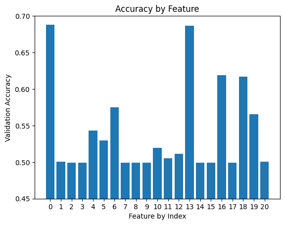

```python
ValidAcc = [0.6882039856417873,
 0.5004862695170902,
 0.4995137304829098,
 0.4995137304829098,
 0.543224939437342,
 0.5298215832935477,
 0.5748236167842555,
 0.4995137304829098,
 0.4995137304829098,
 0.4995137304829098,
 0.5197602249217548,
 0.5051721394090499,
 0.5115732145067459,
 0.6866125581313105,
 0.4995137304829098,
 0.4995137304829098,
 0.618959206408148,
 0.4995137304829098,
 0.6170318108676817,
 0.5656287022792779,
 0.5004862695170902]

x = np.arange(21)
plt.bar(x, ValidAcc)
plt.title('Accuracy by Feature')
plt.xlabel('Feature by Index')
plt.ylabel('Validation Accuracy')
plt.xticks(np.arange(0, 21, 1))
plt.savefig('AccuracyByFeature.png')
plt.ylim(0.45, 0.70)
#plt.legend(loc=4)
plt.show()
```

I quickly generate a 1-1 test model using only the features that produce greater than the ~50% accuracy in the prior analysis. This is a quick-and-dirty assessment to see if I can save time on the feature reduction process.

However, we can see the accuracy drops fair amount over the baseline 1-1 model I built earlier.

```
Epoch 115: early stopping

TRAINING SET ACCURACY:  0.7278257179233272

VALIDATION SET ACCURACY:  0.7303768146694252
```

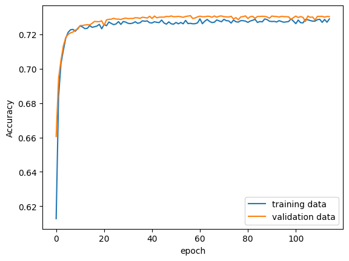

```python
Xt = XTRAIN[:,[0,4,5,6,10,12,13,16,18,19]]
Xv = XVALID[:,[0,4,5,6,10,12,13,16,18,19]]
full_reduced = build_model([1, 1], Xt, YTRAIN, Xv, YVALID, 512, 32, 0)
print()
plot_history(full_reduced)
```

Below, I extract the header values, so that I have an overview of what features are in my set.

```python
list(df.columns.values)
```

```
['Diabetes_binary',
 'HighBP',
 'HighChol',
 'CholCheck',
 'BMI',
 'Smoker',
 'Stroke',
 'HeartDiseaseorAttack',
 'PhysActivity',
 'Fruits',
 'Veggies',
 'HvyAlcoholConsump',
 'AnyHealthcare',
 'NoDocbcCost',
 'GenHlth',
 'MentHlth',
 'PhysHlth',
 'DiffWalk',
 'Sex',
 'Age',
 'Education',
 'Income']
```

This following section may be a bit difficult to follow.

However, I automate the construction of models by using a function that iteratively drops the selected features in the "dropArray" and returns the accuracy.

I manually remove the feature from the data set for the next function call. In this manner I can guide my feature reduction process. I use a high batch number (i.e. 822) to speed up the process. The process does produce inconsistent validation accuracies, but it is sufficient for a fast pass analysis.

```python
def build_modified(neuron_arr, XTRAIN, YTRAIN, XVALID, YVALID, num_epochs, num_batch, is_verbose):
  length = len(neuron_arr)
  my_model = Sequential()
  #
  if length == 1:
    my_model.add(Dense(neuron_arr[0], input_dim = len(XTRAIN[0, :]), activation='sigmoid'))
  elif length == 2:
    my_model.add(Dense(neuron_arr[0], input_dim = len(XTRAIN[0, :]), activation='relu'))
    my_model.add(Dense(neuron_arr[1], activation='sigmoid'))
  else:
    for i in range(0, length-1):
      my_model.add(Dense(neuron_arr[i], activation='relu'))
    my_model.add(Dense(neuron_arr[length-1], activation='sigmoid'))
  #
  my_model.compile(loss='binary_crossentropy', optimizer='rmsprop', metrics=['accuracy'])
  callback_a = ModelCheckpoint(filepath = 'my_best', monitor='val_loss', save_best_only = True, save_weights_only = True, verbose = 0)
  callback_b = EarlyStopping(monitor='val_loss', mode='min', patience=20, verbose=1)
  history = my_model.fit(XTRAIN, YTRAIN, validation_data = (XVALID, YVALID), epochs=num_epochs, batch_size=num_batch, verbose=is_verbose, callbacks = [callback_a, callback_b])
  return history

def drop_feature(dropArray, X_TRAIN, Y_TRAIN, X_VALID, Y_VALID):
  accuracyArr = [0] * 21
  for i in dropArray:
    newXTRAIN = np.delete(X_TRAIN, i, axis=1)
    newXVALID = np.delete(X_VALID, i, axis=1)
    my_model = build_modified([1, 1], newXTRAIN, Y_TRAIN, newXVALID, Y_VALID, 512, 822, 0)
    accuracyArr[i] = accuracy_score(YVALID, (my_model.model.predict(newXVALID) > 0.5).astype(int))
    print("For dropped element \'", header[i],"\'", ", index =" , i, ", accuracy = ", accuracyArr[i])
  return accuracyArr
```

This default model gives a rough estimation of the the baseline validation accuracy for model using all the features and the larger batch size.

```
TRAINING SET ACCURACY:  0.7454378271325506

VALIDATION SET ACCURACY:  0.7461142644952522
```

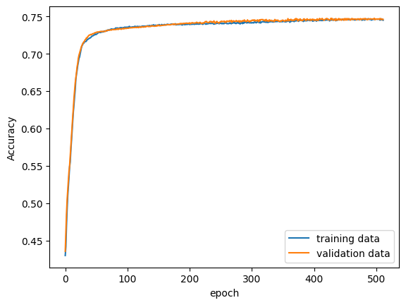

```python
# 1-1 Control Model for batch size - 822
controlModel = build_model([1, 1], XTRAIN, YTRAIN, XVALID, YVALID, 512, 822, 0)
print()
plot_history(controlModel)
```

```python
acc1 = drop_feature([1, 2, 3, 7, 8, 9, 14, 15, 17, 20], XTRAIN, YTRAIN, XVALID, YVALID)
```

```
For dropped element ' HighChol ' , index = 1 , accuracy =  0.7390589358654713
Epoch 24: early stopping
For dropped element ' CholCheck ' , index = 2 , accuracy =  0.4995137304829098
For dropped element ' BMI ' , index = 3 , accuracy =  0.7340017328877336
For dropped element ' PhysActivity ' , index = 7 , accuracy =  0.745902074160522
Epoch 21: early stopping
For dropped element ' Fruits ' , index = 8 , accuracy =  0.4995137304829098
For dropped element ' Veggies ' , index = 9 , accuracy =  0.7453892808515905
For dropped element ' MentHlth ' , index = 14 , accuracy =  0.7462557247184057
For dropped element ' PhysHlth ' , index = 15 , accuracy =  0.7441691864268916
For dropped element ' Sex ' , index = 17 , accuracy =  0.7444521068731986
For dropped element ' Income ' , index = 20 , accuracy =  0.7432850600321822
```

Dropping 'MentHlth' column from the dataset.

```python
header = list(df.columns.values)
header = header[1:]
x = 14
header = np.delete(header, x)
drop_XTRAIN = np.delete(XTRAIN, x, axis=1)
drop_XVALID = np.delete(XVALID, x, axis=1)
print(header)
```

```
['HighBP' 'HighChol' 'CholCheck' 'BMI' 'Smoker' 'Stroke'
 'HeartDiseaseorAttack' 'PhysActivity' 'Fruits' 'Veggies'
 'HvyAlcoholConsump' 'AnyHealthcare' 'NoDocbcCost' 'GenHlth' 'PhysHlth'
 'DiffWalk' 'Sex' 'Age' 'Education' 'Income']
```

```python
acc2 = drop_feature([1, 2, 3, 7, 8, 9, 14, 16, 19], drop_XTRAIN, YTRAIN, drop_XVALID, YVALID)
```

```
Epoch 30: early stopping
For dropped element ' HighChol ' , index = 1 , accuracy =  0.4995137304829098
Epoch 33: early stopping
For dropped element ' CholCheck ' , index = 2 , accuracy =  0.4995137304829098
Epoch 21: early stopping
For dropped element ' BMI ' , index = 3 , accuracy =  0.4995137304829098
Epoch 27: early stopping
For dropped element ' PhysActivity ' , index = 7 , accuracy =  0.4995137304829098
Epoch 29: early stopping
For dropped element ' Fruits ' , index = 8 , accuracy =  0.4995137304829098
Epoch 24: early stopping
For dropped element ' Veggies ' , index = 9 , accuracy =  0.4995137304829098
Epoch 21: early stopping
For dropped element ' PhysHlth ' , index = 14 , accuracy =  0.4995137304829098
For dropped element ' Sex ' , index = 16 , accuracy =  0.743833218396902
For dropped element ' Income ' , index = 19 , accuracy =  0.7442399165384683
```

Dropping 'Income' column from the dataset.

```python
x= 19
header = np.delete(header, x)
drop_XTRAIN = np.delete(drop_XTRAIN, x, axis=1)
drop_XVALID = np.delete(drop_XVALID, x, axis=1)
print(header)
```

```
['HighBP' 'HighChol' 'CholCheck' 'BMI' 'Smoker' 'Stroke'
 'HeartDiseaseorAttack' 'PhysActivity' 'Fruits' 'Veggies'
 'HvyAlcoholConsump' 'AnyHealthcare' 'NoDocbcCost' 'GenHlth' 'PhysHlth'
 'DiffWalk' 'Sex' 'Age' 'Education']
```

```python
acc3 = drop_feature([1, 2, 3, 7, 8, 9, 14, 16], drop_XTRAIN, YTRAIN, drop_XVALID, YVALID)
```

```
Epoch 26: early stopping
For dropped element ' HighChol ' , index = 1 , accuracy =  0.4995137304829098
Epoch 24: early stopping
For dropped element ' CholCheck ' , index = 2 , accuracy =  0.4994606828992273
For dropped element ' BMI ' , index = 3 , accuracy =  0.7324456704330451
Epoch 21: early stopping
For dropped element ' PhysActivity ' , index = 7 , accuracy =  0.4995137304829098
Epoch 25: early stopping
For dropped element ' Fruits ' , index = 8 , accuracy =  0.4995137304829098
For dropped element ' Veggies ' , index = 9 , accuracy =  0.7442752815942567
Epoch 35: early stopping
For dropped element ' PhysHlth ' , index = 14 , accuracy =  0.4995137304829098
For dropped element ' Sex ' , index = 16 , accuracy =  0.7414814421869751
```

Dropping 'Veggies' column from the dataset.

```python
x = 9
header = np.delete(header, x)
drop_XTRAIN = np.delete(drop_XTRAIN, x, axis=1)
drop_XVALID = np.delete(drop_XVALID, x, axis=1)
print(header)
```

```
['HighBP' 'HighChol' 'CholCheck' 'BMI' 'Smoker' 'Stroke'
 'HeartDiseaseorAttack' 'PhysActivity' 'Fruits' 'HvyAlcoholConsump'
 'AnyHealthcare' 'NoDocbcCost' 'GenHlth' 'PhysHlth' 'DiffWalk' 'Sex' 'Age'
 'Education']
```

```python
acc4 = drop_feature([1, 2, 3, 7, 8, 13, 15], drop_XTRAIN, YTRAIN, drop_XVALID, YVALID)
```

```
Epoch 21: early stopping
For dropped element ' HighChol ' , index = 1 , accuracy =  0.4995137304829098
Epoch 21: early stopping
For dropped element ' CholCheck ' , index = 2 , accuracy =  0.4995137304829098
For dropped element ' BMI ' , index = 3 , accuracy =  0.7334005269393312
For dropped element ' PhysActivity ' , index = 7 , accuracy =  0.7433027425600763
For dropped element ' Fruits ' , index = 8 , accuracy =  0.7440277262037381
For dropped element ' PhysHlth ' , index = 13 , accuracy =  0.7451947730447545
For dropped element ' Sex ' , index = 15 , accuracy =  0.743833218396902
```

Dropping 'PhysHlth' column from the dataset.

```python
x = 13
header = np.delete(header, x)
drop_XTRAIN = np.delete(drop_XTRAIN, x, axis=1)
drop_XVALID = np.delete(drop_XVALID, x, axis=1)
print(header)
```

```
['HighBP' 'HighChol' 'CholCheck' 'BMI' 'Smoker' 'Stroke'
 'HeartDiseaseorAttack' 'PhysActivity' 'Fruits' 'HvyAlcoholConsump'
 'AnyHealthcare' 'NoDocbcCost' 'GenHlth' 'DiffWalk' 'Sex' 'Age'
 'Education']
```

```python
acc5 = drop_feature([1, 2, 3, 7, 8, 14], drop_XTRAIN, YTRAIN, drop_XVALID, YVALID)
```

```
For dropped element ' HighChol ' , index = 1 , accuracy =  0.7394302689512493
Epoch 21: early stopping
For dropped element ' CholCheck ' , index = 2 , accuracy =  0.4995137304829098
For dropped element ' BMI ' , index = 3 , accuracy =  0.7325517656004102
Epoch 22: early stopping
For dropped element ' PhysActivity ' , index = 7 , accuracy =  0.4995137304829098
Epoch 21: early stopping
For dropped element ' Fruits ' , index = 8 , accuracy =  0.4995137304829098
Epoch 27: early stopping
For dropped element ' Sex ' , index = 14 , accuracy =  0.4995137304829098
```

Dropping 'HighChol' column from the dataset.

```python
x = 1
header = np.delete(header, x)
drop_XTRAIN = np.delete(drop_XTRAIN, x, axis=1)
drop_XVALID = np.delete(drop_XVALID, x, axis=1)
print(header)
```

```
['HighBP' 'CholCheck' 'BMI' 'Smoker' 'Stroke' 'HeartDiseaseorAttack'
 'PhysActivity' 'Fruits' 'HvyAlcoholConsump' 'AnyHealthcare' 'NoDocbcCost'
 'GenHlth' 'DiffWalk' 'Sex' 'Age' 'Education']
```

```python
acc6 = drop_feature([1, 2, 6, 7, 13], drop_XTRAIN, YTRAIN, drop_XVALID, YVALID)
```

```
Epoch 24: early stopping
For dropped element ' CholCheck ' , index = 1 , accuracy =  0.4995137304829098
Epoch 22: early stopping
For dropped element ' BMI ' , index = 2 , accuracy =  0.4995137304829098
Epoch 59: early stopping
For dropped element ' PhysActivity ' , index = 6 , accuracy =  0.4995137304829098
For dropped element ' Fruits ' , index = 7 , accuracy =  0.7384400473891748
Epoch 31: early stopping
For dropped element ' Sex ' , index = 13 , accuracy =  0.4995137304829098
```

Dropping 'Fruits' column from the dataset.

```python
x = 7
header = np.delete(header, x)
drop_XTRAIN = np.delete(drop_XTRAIN, x, axis=1)
drop_XVALID = np.delete(drop_XVALID, x, axis=1)
print(header)
```

```
['HighBP' 'CholCheck' 'BMI' 'Smoker' 'Stroke' 'HeartDiseaseorAttack'
 'PhysActivity' 'HvyAlcoholConsump' 'AnyHealthcare' 'NoDocbcCost'
 'GenHlth' 'DiffWalk' 'Sex' 'Age' 'Education']
```

```python
acc7 = drop_feature([1, 2, 6, 12], drop_XTRAIN, YTRAIN, drop_XVALID, YVALID)
```

```
For dropped element ' CholCheck ' , index = 1 , accuracy =  0.7386168726681166
For dropped element ' BMI ' , index = 2 , accuracy =  0.7289445299099959
Epoch 21: early stopping
For dropped element ' PhysActivity ' , index = 6 , accuracy =  0.4995137304829098
Epoch 44: early stopping
For dropped element ' Sex ' , index = 12 , accuracy =  0.4995137304829098
```

Dropping 'CholCheck' from the dataset.

```python
x = 1
header = np.delete(header, x)
drop_XTRAIN = np.delete(drop_XTRAIN, x, axis=1)
drop_XVALID = np.delete(drop_XVALID, x, axis=1)
print(header)
```

```
['HighBP' 'BMI' 'Smoker' 'Stroke' 'HeartDiseaseorAttack' 'PhysActivity'
 'HvyAlcoholConsump' 'AnyHealthcare' 'NoDocbcCost' 'GenHlth' 'DiffWalk'
 'Sex' 'Age' 'Education']
```

```python
acc8 = drop_feature([1, 5, 11], drop_XTRAIN, YTRAIN, drop_XVALID, YVALID)
```

```
For dropped element ' BMI ' , index = 1 , accuracy =  0.7266104362279632
For dropped element ' PhysActivity ' , index = 5 , accuracy =  0.7372199529644758
Epoch 26: early stopping
For dropped element ' Sex ' , index = 11 , accuracy =  0.4995137304829098
```

Our fast pass feature-reduction analysis completed, I extract the features by index.

```python
header_again = list(df.columns.values)
header_again = header_again[1:]
print('index 14 -->', header_again[14])
print('index 20 -->', header_again[20])
print('index  9 -->', header_again[9])
print('index  15 -->', header_again[15])
print('index  1 -->', header_again[1])
print('index  8 -->', header_again[8])
```

```
index 14 --> MentHlth
index 20 --> Income
index  9 --> Veggies
index  15 --> PhysHlth
index  1 --> HighChol
index  8 --> Fruits
```

Next, I construct more thorough models using the smaller batch sizes and progressively remove more features until we hit an model that produces a similar validation accuracy our baseline expectation.

```
Epoch 145: early stopping

TRAINING SET ACCURACY:  0.7503890224925732

VALIDATION SET ACCURACY:  0.7485190882888618
```

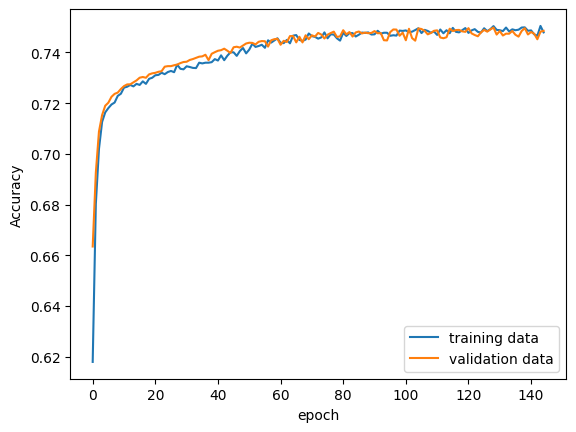

```python
Xt = np.delete(XTRAIN, 14, axis=1)
Xv = np.delete(XVALID, 14, axis=1)

reduction1 = build_model([1, 1], Xt, YTRAIN, Xv, YVALID, 512, 32, 0)
print()
plot_history(reduction1)
```

```
Epoch 148: early stopping

TRAINING SET ACCURACY:  0.7489743952468525

VALIDATION SET ACCURACY:  0.7481300726751896
```

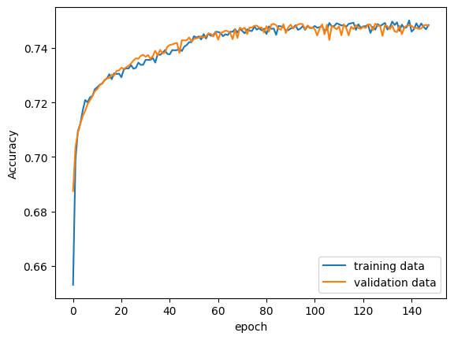

```python
Xt = np.delete(XTRAIN, [14,20], axis=1)
Xv = np.delete(XVALID, [14,20], axis=1)

reduction2 = build_model([1, 1], Xt, YTRAIN, Xv, YVALID, 512, 32, 0)
print()
plot_history(reduction2)
```

```
Epoch 161: early stopping

TRAINING SET ACCURACY:  0.7486207384354223

VALIDATION SET ACCURACY:  0.7470514384736442
```

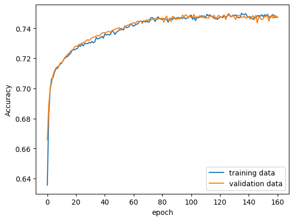

```python
Xt = np.delete(XTRAIN, [14,20,9], axis=1)
Xv = np.delete(XVALID, [14,20,9], axis=1)

reduction3 = build_model([1, 1], Xt, YTRAIN, Xv, YVALID, 512, 32, 0)
print()
plot_history(reduction3)
```

```
Epoch 141: early stopping

TRAINING SET ACCURACY:  0.7498231715942849

VALIDATION SET ACCURACY:  0.7484660407051792
```

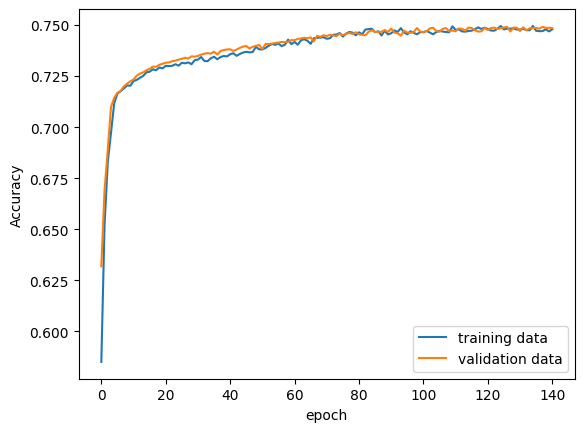

```python
Xt = np.delete(XTRAIN, [14,20,9,15], axis=1)
Xv = np.delete(XVALID, [14,20,9,15], axis=1)

reduction4 = build_model([1, 1], Xt, YTRAIN, Xv, YVALID, 512, 32, 0)
print()
plot_history(reduction4)
```

```
Epoch 163: early stopping

TRAINING SET ACCURACY:  0.7452256330456924

VALIDATION SET ACCURACY:  0.744593567096352
```

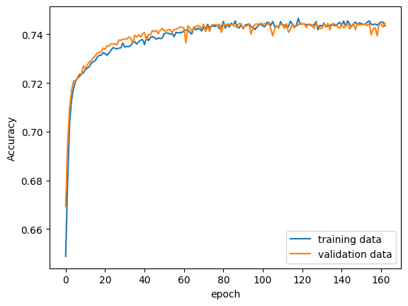

```python
Xt = np.delete(XTRAIN, [14,20,9,15,1], axis=1)
Xv = np.delete(XVALID, [14,20,9,15,1], axis=1)

reduction5 = build_model([1, 1], Xt, YTRAIN, Xv, YVALID, 512, 32, 0)
print()
plot_history(reduction5)
```

```
Epoch 172: early stopping

TRAINING SET ACCURACY:  0.7452256330456924

VALIDATION SET ACCURACY:  0.744399059289516
```

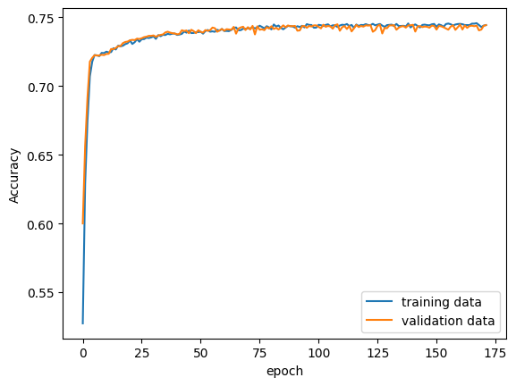

```python
Xt = np.delete(XTRAIN, [14,20,9,15,1,8], axis=1)
Xv = np.delete(XVALID, [14,20,9,15,1,8], axis=1)

reduction6 = build_model([1, 1], Xt, YTRAIN, Xv, YVALID, 512, 32, 0)
print()
plot_history(reduction6)
```

Below lies an array transcribed from the accuracies produced by each model.

```python
finalAcc = [0.7488196912630629, 0.7485190882888618, 0.7481300726751896, 0.7470514384736442, 0.7484660407051792, 0.744593567096352, 0.744399059289516]
```

I graph the results by each model.

The model numbers correspond to those of the variable names storing the returns of each function.

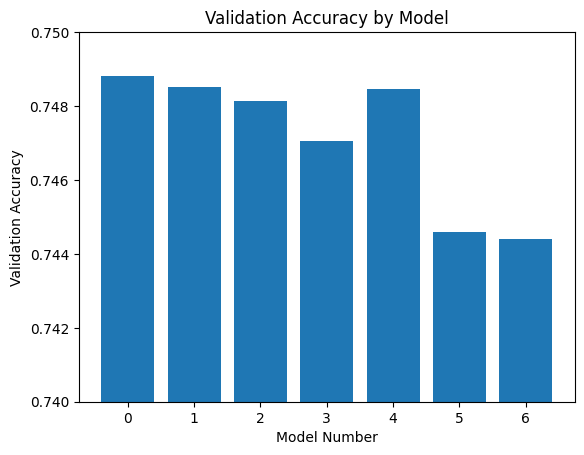

```python
x = np.arange(7)
plt.bar(x, finalAcc)
plt.title('Validation Accuracy by Model')
plt.xlabel('Model Number')
plt.ylabel('Validation Accuracy')
#plt.xticks(np.arange(0, 7, 1))
plt.savefig('AccuracyByModel.png')
plt.ylim(0.740, 0.750)
#plt.legend(loc=4)
plt.show()
```

The model number corresponds also corresponds to the number of features removed. The selected features are dropped in the same order that they were tested above.

We can see that we can remove four features while retaining a good accuracy. The dropped features correspond to mental health, income, vegetable consumption and physical health.

In conclusion, I believe that this data set is not good for making precise predictions about diabetes. Most of these factors might reasonably be correlated to diabetes, but is not directly causative. So while a high BMI might be weakly associated with diabetes, a good majority of people with high BMI do not have diabetes.

By that token, something a blood sugar testm properly administrated by a professional, would be more directly indicative. As such, my take away lesson is that just because datasets are widely available does not mean that the data is of good quality. Much of what we compulsively hoard online is not good for anything.

Data scientists can only do so much if the methodology for acquiring data is flawed or if those gathering it have a poor understanding of the domain.

```python
%%shell
jupyter nbconvert --to html /content/Final_Project_CS5300_ChrisHan.ipynb
```

```
[NbConvertApp] Converting notebook /content/Final_Project_CS5300_ChrisHan.ipynb to html
[NbConvertApp] Writing 1679067 bytes to /content/Final_Project_CS5300_ChrisHan.html
```